# Experiment 3: Modelling with and without causality (non-linear problem)

The goal of this experiment is to check if having causality information of the variables of our data set is useful to improve our models.

The experiment has the following steps:

1. Define a causal graph (Directed Acyclic graph) relating five (5) hypothetical variables. Some of them will be supposed to be unknown.
2. Define causal rules between those variables
3. Generate a data set following the rules
4. Train a general ML model on the data set in order to predict the effect of X into Y
5. Train a general ML model on the data set using the causal information in order to predict the effect of X into Y.
6. Compare the performance of the two approaches:
   1. On unseen data that follows the distribution of the training set
   2. On unseen data that does not follow the distribution of the training set

## 1. Define a causal graph

Here I define a causal graph whose relations may cause problems if not adequately treated. Nodes in gray will not be visible in the dataset.

```python
import numpy as np
import pandas as pd
import pandas_profiling as pp
import plotly_express as px

from sklearn.model_selection import train_test_split
from sklearn.tree import DecisionTreeRegressor
from sklearn.metrics import accuracy_score

import networkx as nx
from nxpd import draw

np.random.seed(seed=42)
```

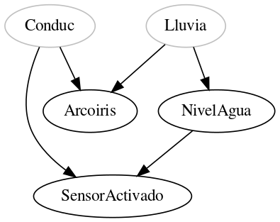

```python
G = nx.DiGraph()
G.graph['dpi'] = 120
G.add_nodes_from(['NivelAgua', ('Lluvia',{'color':'gray'}), 'Arcoiris', ('Conduc',{'color':'gray'}), 'SensorActivado'])
G.add_edges_from([('Lluvia','NivelAgua'),('Conduc','Arcoiris'),('Lluvia','Arcoiris'),('Conduc','SensorActivado'),('NivelAgua','SensorActivado')])
draw(G, show='ipynb')
```

The problem presented to the ML practitioner will be:

**Can you estimate the real influence of X in Y?**  
**I mean, what happens to Y when I increase X by one unit, keeping all the same equal?**

## 2-3. Define causal rules between variables and create data set

Let's define some rules to later generate a data set:

```python
n = 10000
```

```python
sigma_lluvia = 10
mu_lluvia = 20
Lluvia = sigma_lluvia * np.random.randn(n,1) + mu_lluvia

sigma_conduc = 10
mu_conduc = 50
Conduc = sigma_conduc * np.random.randn(n,1) + mu_conduc
```

```python
Arcoiris = np.zeros_like(Lluvia)
Arcoiris[np.logical_and(Lluvia > 20, Conduc > 40)] = 1

NivelAgua = 0.5 * Lluvia + np.random.randn(n,1)

SensorActivado = np.zeros_like(Lluvia)
SensorActivado[Conduc > 40] = 1
SensorActivado[np.logical_and(Conduc <= 40, NivelAgua > 20)] = 1
SensorActivado[np.logical_and(Conduc <= 40, NivelAgua <= 20)] = 0
```

```python
df_data = np.concatenate((Lluvia,Conduc,Arcoiris,NivelAgua,SensorActivado), axis=1)
df = pd.DataFrame(data=df_data, columns=['Lluvia','Conduc','Arcoiris','NivelAgua','SensorActivado'])
df.head()
```

|  | Lluvia | Conduc | Arcoiris | NivelAgua | SensorActivado |
| --- | --- | --- | --- | --- | --- |
| 0 | 18.137797 | 53.300868 | 0.0 | 9.111020 | 1.0 |
| 1 | 26.527795 | 51.097264 | 1.0 | 13.045299 | 1.0 |
| 2 | 24.180403 | 40.484152 | 1.0 | 13.331541 | 1.0 |
| 3 | 12.181296 | 43.631602 | 0.0 | 5.212949 | 1.0 |
| 4 | 24.159035 | 46.224568 | 1.0 | 12.660389 | 1.0 |

## Prepare training set

```python
X_train, X_test, y_train, y_test = train_test_split(df.drop(columns='SensorActivado'), df[['SensorActivado']], test_size=0.3, random_state=42)
```

```python
y_train = np.squeeze(y_train)
y_test  = np.squeeze(y_test)
```

```python
df_real = df[['Arcoiris','NivelAgua','SensorActivado']]
X_train_real = X_train[['Arcoiris','NivelAgua']]
X_test_real = X_test[['Arcoiris','NivelAgua']]
df_real.head()
```

|  | Arcoiris | NivelAgua | SensorActivado |
| --- | --- | --- | --- |
| 0 | 0.0 | 9.111020 | 1.0 |
| 1 | 1.0 | 13.045299 | 1.0 |
| 2 | 1.0 | 13.331541 | 1.0 |
| 3 | 0.0 | 5.212949 | 1.0 |
| 4 | 1.0 | 12.660389 | 1.0 |

## Explore data set

```python
pp.ProfileReport(df, style={'full_width':True})
```

[interactive chart not shown]

```python
px.box(data_frame=df, y='NivelAgua', x='SensorActivado')
```

[interactive chart not shown]

```python
df.groupby('Arcoiris').count()['SensorActivado']
```

```
Arcoiris
0.0    5715
1.0    4285
Name: SensorActivado, dtype: int64
```

## 4. Train a general ML model on the data set

Let's try a Decision Tree. I will use both variables, Arcoiris and NivelAgua, to predict SensorActivado:

```python
dt = DecisionTreeRegressor(max_depth=2)
dt.fit(X_train_real, y_train)
predictions_dt = dt.predict(X_test_real) > .5
print("Acc in test set = {}".format(np.round(accuracy_score(predictions_dt, y_test), decimals=3)))
```

```
Acc in test set = 0.899
```

It looks like the model has learned the patterns in the data set quite well

```python
from sklearn.tree import _tree

def tree_to_code(tree, feature_names):
    tree_ = tree.tree_
    feature_name = [
        feature_names[i] if i != _tree.TREE_UNDEFINED else "undefined!"
        for i in tree_.feature
    ]
    print("def tree({}):".format(", ".join(feature_names)))

    def recurse(node, depth):
        indent = "  " * depth
        if tree_.feature[node] != _tree.TREE_UNDEFINED:
            name = feature_name[node]
            threshold = tree_.threshold[node]
            print("{}if {} <= {}:".format(indent, name, threshold))
            recurse(tree_.children_left[node], depth + 1)
            print("{}else:  # if {} > {}".format(indent, name, threshold))
            recurse(tree_.children_right[node], depth + 1)
        else:
            print("{}return {}".format(indent, tree_.value[node]))

    recurse(0, 1)
```

```python
tree_to_code(dt, ['Arcoiris', 'NivelAgua'])
```

```
def tree(Arcoiris, NivelAgua):
  if Arcoiris <= 0.5:
    if NivelAgua <= 10.8264479637146:
      return [[0.82238935]]
    else:  # if NivelAgua > 10.8264479637146
      return [[0.13333333]]
  else:  # if Arcoiris > 0.5
    return [[1.]]
```

El modelo dice que que el corte en NivelAgua está en 10.82, y que a mayor NivelAgua, menor SensorActivado.

¡La relación capturada con el modelo no tiene nada que ver con la realidad! (si NivelAgua > 20 => SensorActivado = 1)

## 5. Train a general ML model using causal information

Looking at the causal graph, it is clear that, in order to get the isolated influence of NivelAgua we need to ignore Arcoiris, as considering it will open the collider path and create a counfounding situation.

So let's try the same model, but training only on NivelAgua:

```python
X_train_causal = X_train[['NivelAgua']]
X_test_causal = X_test[['NivelAgua']]
```

```python
causal_dt = DecisionTreeRegressor(max_depth=1)
causal_dt.fit(X_train_causal, y_train)
predictions_causal_dt = causal_dt.predict(X_test_causal) > .5
print("Acc in Test set = {}".format(np.round(accuracy_score(predictions_causal_dt, y_test), decimals=2)))
```

```
Acc in Test set = 0.84
```

The model is quite worse when predicting SensorActivado (as expected; it is only considering the influence of NivelAgua). It is in fact predicting SensorActivado = 1 for every sample:

```python
np.sum(predictions_causal_dt) / len(predictions_causal_dt)
```

```
1.0
```

But let's see what patterns the model has captured:

```python
tree_to_code(causal_dt, ['NivelAgua'])
```

```
def tree(NivelAgua):
  if NivelAgua <= 19.95685386657715:
    return [[0.84139549]]
  else:  # if NivelAgua > 19.95685386657715
    return [[1.]]
```

If NivelAgua > 20, and whatever value Conduc has, SensorActivado = 1. If NivelAgua < 20, the value of SensorActivado depends totally on the value of Conduc, and probably 84% of those samples have a Conduc value that activates SensorActivado:

```python
np.sum(X_test.loc[X_test.NivelAgua < 20]['Conduc'] > 40) / X_test.shape[0]
```

```
0.8163333333333334
```

Almost as predicted!!

Now, let's see if the theory works. If I train with NivelAgua and Conduc, the model should be able to capture the underlying patters without bias:

```python
causal_dt2 = DecisionTreeRegressor(max_depth=2)
causal_dt2.fit(X_train[['NivelAgua', 'Conduc']], y_train)
predictions_causal_dt2 = causal_dt2.predict(X_test[['NivelAgua', 'Conduc']]) > .5
print("Acc in Test set = {}".format(np.round(accuracy_score(predictions_causal_dt2, y_test), decimals=2)))
```

```
Acc in Test set = 1.0
```

Boom!

It is able to perfectly predict the test set!!

```python
tree_to_code(causal_dt2, ['NivelAgua', 'Conduc'])
```

```
def tree(NivelAgua, Conduc):
  if Conduc <= 39.99171447753906:
    if NivelAgua <= 20.04405975341797:
      return [[0.]]
    else:  # if NivelAgua > 20.04405975341797
      return [[1.]]
  else:  # if Conduc > 39.99171447753906
    return [[1.]]
```

Incredible! The model has captured the exact underlying relationship between the three features!

## 6A. Performance comparison with unseen data

Let's take a reference value:

```python
X_test.head(1)
```

|  | Lluvia | Conduc | Arcoiris | NivelAgua |
| --- | --- | --- | --- | --- |
| 6252 | 33.595751 | 62.591831 | 1.0 | 17.470178 |

What would happen if I increase NivelAgua by ten units?

```python
do_X_test = X_test.copy()
do_X_test[['NivelAgua']] = do_X_test[['NivelAgua']] + 10.
```

```python
do_X_test.head(1)
```

|  | Lluvia | Conduc | Arcoiris | NivelAgua |
| --- | --- | --- | --- | --- |
| 6252 | 33.595751 | 62.591831 | 1.0 | 27.470178 |

**ML answer:**

```python
predictions_ml = dt.predict(do_X_test[['NivelAgua','Arcoiris']])
```

**Causal inference answer:**

```python
predictions_causal_inference = y_test
predictions_causal_inference[do_X_test.NivelAgua > 19.96] = 1
```

**Real answer:**

```python
real_answer = np.zeros_like(predictions_ml)
real_answer[np.logical_and(do_X_test.Conduc <= 40, do_X_test.NivelAgua > 20)] = 1
real_answer[np.logical_and(do_X_test.Conduc <= 40, do_X_test.NivelAgua <= 20)] = 0
real_answer[do_X_test.Conduc > 40] = 1
```

```python
print("Acc ML: {}".format(np.round(accuracy_score(real_answer, predictions_ml), decimals=2)))
print("Acc Causal Inference: {}".format(np.round(accuracy_score(real_answer, predictions_causal_inference), decimals=2)))
```

```
Acc ML: 0.92
Acc Causal Inference: 1.0
```

# Conclusion

- Decisions of feature selection based on causal knowledge are useful for non-linear models too. Interactions are different and model-dependent, but when they occur in a particular order, they are prone to capture spurious correlations if we do not select the appropiate features.
- Modelling with the correct variables helps the model capture **the true underlying causal relationships**.